# A Quantitative Synthesis of Early Language Acquisition Using Meta-Analysis

Supplementary Information

Molly Lewis, Mika Braginsky, Sho Tsuji, Christina Bergmann, Page Piccinini, Alejandrina Cristia, and Michael C. Frank

2017-10-30

```r
# this data is cached by
# scripts/cache_script_data.R
synthesis_meta_data <- read_feather("../paper_data/synthesis_paper_datasets.feather")
synthesis_all_data <- read_feather("../paper_data/synthesis_paper_all_data.feather")
```

This document was created from an [R markdown file](http://github.com/langcog/metalab/blob/master/write-ups/synthesis_paper/SI/synthesis_SI.Rmd). Data from the paper can be interactively explored on the [Metalab website, http://metalab.stanford.edu/](http://metalab.stanford.edu/). The manuscript itself was also produced from an [R markdown file](https://github.com/langcog/metalab/blob/master/write-ups/synthesis_paper/open_mind/metalab_synthesis.Rmd), and thus all analyses presented in the paper can be reproduced from that document.

## Search strategies

Meta-analyses were conducted by the authors for all but two phenomena (IDS preference and Pointing and Vocabulary). Data for these two phenomena were obtained by adapting effect size estimates from existing, published meta-analyses (Dunst, Gorman, & Hamby, 2012; Colonnesi et al., 2010). Across phenomena, meta-analyses varied in their degree of systematicty in selecting papers. In the table below, we describe the search strategy for each phenomenon. Quoted descriptions are taken directly from the published source. Note that across all meta-analyses, we included only those conditions that tested typically-developing monolinguals.

```r
methods.table <- synthesis_meta_data %>% select(name,
    search_strategy, internal_citation) %>% mutate(name = fct_recode(name,
    `IDS preference` = "Infant directed speech preference",
    `Statistical sound learning` = "Statistical sound category learning",
    `Concept-label advantage` = "Label advantage in concept learning",
    `Vowel discrim. (native)` = "Vowel discrimination (native)",
    `Vowel discrim. (non-native)` = "Vowel discrimination (non-native)")) %>%
    mutate(name = paste(name, internal_citation)) %>%
    select(-internal_citation) %>% .[c(1, 6, 4, 5,
    7, 8, 10, 12, 2, 9, 3, 11), ] %>% rename(Phenomenon = name,
    `Search Strategy` = search_strategy)
```

```r
kable(methods.table, row.names = F)
```

| Phenomenon | Search Strategy |
| --- | --- |
| IDS preference (Dunst, Gorman, & Hamby, 2012) | “Studies were located using motherese or parentese or fatherese or infant directed speech or infant-directed speech or infant directed talk or child directed speech or child-directed speech or child d… |
| Phonotactic learning (Cristia, in prep.) | “Studies were considered based on a forward search from the seminal paper (MWG02) on both pubmed and google search, a list of references produced by the author, direct contact of labs having published… |
| Vowel discrim. (native) (Tsuji & Cristia, 2014) | “A full search on scholar.google.com was conducted in September 2012 with the keyword combination “{infant\|infancy} & {vowel\|speech sound\|syllable} & discrimination.” Additionally, the search terms… |
| Vowel discrim. (non-native) (Tsuji & Cristia, 2014) | See Native Vowel Discrimination, above. |
| Statistical sound learning (Cristia, in prep.) | “Studies were considered based on a forward search from the seminal paper (MWG02) on both pubmed and google search, a list of references produced by the author, manual inspection of several editions o… |
| Word segmentation (Bergmann & Cristia, 2015) | “We first generated a list of potentially relevant items to be included in our meta-analysis using the Google Scholar search engine, with the broad search term ‘infant word segmentation’ (following Ge… |
| Mutual exclusivity (Lewis & Frank, in prep.) | “We conducted a forward search based on citations of Markman and Wachtel (1988) in Google Scholar (September 2013). We also searched from papers using the keyword combination ``mutual exclusivity’’ in… |
| Sound symbolism (Lammertink et al., 2016) | “We followed the PRISMA statement (Moher, Liberati, Tetzlaff, Altmann, & The PRISMA Group, 2009) for selecting and reporting on the studies to be included in our meta-analysis. We decided to include a… |
| Concept-label advantage (Lewis & Long, unpublished) | “We conducted a forward search based on Balaban and Waxman (1997) in Google Scholar and Web of Science (October 2015). This was supplemented with papers identified through citations and publication li… |
| Online word recognition (Frank, Lewis, & MacDonald, 2016) | “We conducted a systematic literature review by using Google Scholar to identify peer-reviewed papers citing Fernald et al. (1998). We screened this sample manually to find the subsample of 12 papers … |
| Gaze following (Frank, Lewis, & MacDonald, 2016) | “We identified papers using a Google Scholar search for “gaze following” and included those studies that (a) included data from typically-developing children, (b) used a standard face-to-face gaze-fol… |
| Pointing and vocabulary (Colonnesi et al., 2010) | “The search method involved inspection of digital databases (Web of Knowledge, Picarta, PsychInfo) using the following keywords: pointing, gesture, declarative, imperative, precursors, language, words… |

## Statistical approach

Effect sizes were computed by a script, compute_es.R, available in the Github repository. We calculated effect sizes from reported means and standard deviations where available, otherwise we relied on reported test-statistics (*t* and *F*). Several pre-existing MAs deal with special cases, and these are listed in the script. Except where noted, formulas are from [Hedges & Olkin’s textbook](http://www.amazon.com/Statistical-Methods-Meta-Analysis-Larry-Hedges/dp/0123363802) (2014). All analyses were conducted with the [metafor](http://www.metafor-project.org/doku.php) package (Viechtbauer, 2010) using mixed-effect models, with the exception funnel-skew (Egger’s) test. The funnel-skew test is not implemented in metafor for mixed-effect models, and so we used random-effect models for these analyses. Below is the formula used for our mixed-effect meta-analytic effect size estimates.

```
 model <- metafor::rma.mv(yi = d_calc, V = d_var_calc, random = ~ 1 | short_cite, data = ma_data)
```

## Funnel plots

```r
funnel.es.with.outliers <- synthesis_all_data %>% mutate(dataset = as.factor(dataset),
    dataset = gdata::reorder.factor(dataset, new.order = c(2,
        6, 10, 11, 9, 12, 4, 8, 3, 5, 1, 7)), dataset = plyr::revalue(dataset,
        c(`Infant directed speech preference` = "IDS preference",
            `Statistical sound category learning` = "Statistical sound learning",
            `Label advantage in concept learning` = "Concept-label advantage",
            `Vowel discrimination (native)` = "Vowel discrimination\n(native)",
            `Vowel discrimination (non-native)` = "Vowel discrimination\n(non-native)"))) %>%
    group_by(dataset) %>% mutate(outlier = ifelse(d_calc >
    mean(d_calc) + (3 * sd(d_calc)) | d_calc < mean(d_calc) -
    (3 * sd(d_calc)), 1, 0), outlier = as.factor(outlier))
```

If an effect size is an extreme outlier from the overall mean, this may indicate that the effect size estimates a different psychological phenomenon than the one estimated by others in the sample. One approach for dealing with this type of heterogenity is to exclude outliers from analyses. Here we present funnel plots that exclude effect sizes that lie 3 standard deviations above or below the mean effect size for each meta-analysis. Of the 779 effect sizes in the dataset, 7 were outliers (0.9%).

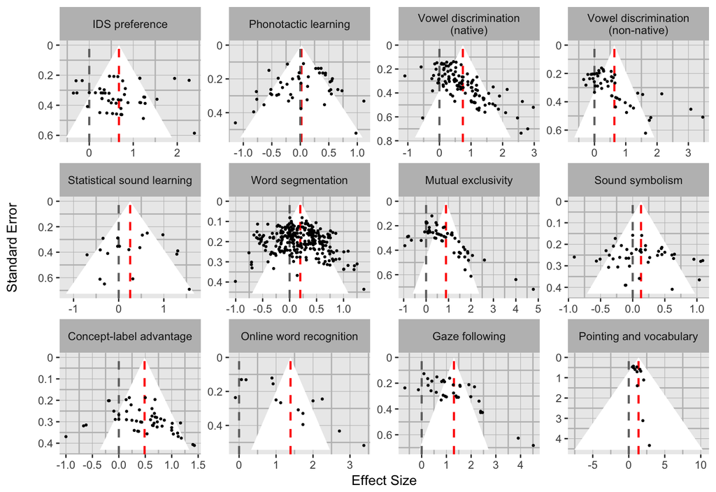

Figure S1: Funnel plots for each meta-analysis with outliers excluded. Each effect size estimate is represented by a point, and the mean effect size is shown as a red dashed line. The grey dashed line shows an effect size of zero. The funnel corresponds to a 95% CI around this mean.

```r
CRIT_95 <- 1.96

funnel.es.data = funnel.es.with.outliers %>% filter(outlier ==
    0) %>% mutate(se = sqrt(d_var_calc), es = d_calc,
    center = mean(d_calc), lower_lim = max(se) + 0.05 *
        max(se))

# separate df for 95 CI funnel shape
funnel95.data.wide <- funnel.es.data %>% select(center,
    lower_lim, dataset) %>% group_by(dataset) %>% summarise(x1 = (center -
    lower_lim * CRIT_95)[1], x2 = center[1], x3 = center[1] +
    lower_lim[1] * CRIT_95, y1 = -lower_lim[1], y2 = 0,
    y3 = -lower_lim[1])

funnel95.data.x <- funnel95.data.wide %>% select(dataset,
    dplyr::contains("x")) %>% gather("coordx", "x",
    2:4) %>% arrange(dataset, coordx) %>% select(-coordx)

funnel95.data.y <- funnel95.data.wide %>% select(dataset,
    dplyr::contains("y")) %>% gather("coordy", "y",
    2:4) %>% arrange(dataset, coordy) %>% select(-coordy)

funnel95.data = bind_cols(funnel95.data.x, funnel95.data.y)

ggplot(funnel.es.data, aes(x = es, y = -se)) + facet_wrap(~dataset,
    scales = "free") + xlab("Effect Size") + ylab("Standard Error\n") +
    scale_colour_solarized(name = "") + geom_polygon(aes(x = x,
    y = y), data = funnel95.data, fill = "white") +
    geom_vline(aes(xintercept = x2), linetype = "dashed",
        color = "red", size = 0.8, data = funnel95.data.wide) +
    geom_vline(xintercept = 0, linetype = "dashed",
        color = "grey44", size = 0.8) + scale_y_continuous(labels = function(x) {
    abs(x)
}) + geom_point(size = 0.5) + theme(panel.grid.major = element_line(colour = "grey",
    size = 0.2), panel.grid.minor = element_line(colour = "grey",
    size = 0.5), strip.text.x = element_text(size = 9),
    strip.background = element_rect(fill = "grey"))
```

```r
eggers.data.f = synthesis_all_data %>%
  group_by(dataset) %>%
  mutate(outlier = ifelse(d_calc > mean(d_calc)  + (3 * sd(d_calc)) |
                            d_calc < mean(d_calc)  - (3 * sd(d_calc)), 1, 0),
         outlier = as.factor(outlier)) %>%
  filter(outlier == 0) %>%
  ungroup() %>%
  split(.$short_name) %>%
  map_df(function(ma_data) eggers_tests(ma_data)) %>%
  mutate(egg.random.z = round(egg.random.z, digits = 2),
         egg.random.p = round(egg.random.p, digits = 2),
         egg_string.f = paste0(egg.random.z, " (", egg.random.p, ")")) %>%
  select(dataset, egg_string.f)

eggers.data.all = synthesis_all_data %>%
  group_by(dataset) %>%
  ungroup() %>%
  split(.$short_name) %>%
  map_df(function(ma_data) eggers_tests(ma_data)) %>%
  mutate(egg.random.z = round(egg.random.z, digits = 2),
         egg.random.p = round(egg.random.p, digits = 2),
         egg_string.all = paste0(egg.random.z, " (", egg.random.p, ")")) %>%
  select(dataset, egg_string.all)

eggers_df <- left_join(eggers.data.all, eggers.data.f) %>%
              ungroup() %>%
             .[c(2,8,3,4,10,5,7,11,6,12,1,9),]  %>% # reorder rows
              left_join(select(synthesis_meta_data, name, short_name),
                        by = c("dataset" = "short_name" )) %>%
              select(-dataset) %>%
              mutate(dataset = fct_recode(name,
                    "IDS preference" = "Infant directed speech preference",
                    "Statistical sound learning" = "Statistical sound category learning",
                    "Concept-label advantage" = "Label advantage in concept learning"),
                    egg_string.f = sub("(0)", "(< .01)", egg_string.f, fixed = TRUE),
                    egg_string.all = sub("(0)", "(< .01)", egg_string.all, fixed = TRUE)) %>%
              select(dataset, egg_string.all, egg_string.f)

kable(eggers_df, col.names = c("Phenomenon", "funnel skew (all conditions)",
                                  "funnel skew (excluding outliers)"),
                    align = c("l", "r", "r"))
```

| Phenomenon | funnel skew (all conditions) | funnel skew (excluding outliers) |
| --- | --- | --- |
| IDS preference | 1.5 (0.13) | 0.46 (0.65) |
| Phonotactic learning | -1.36 (0.18) | -1.36 (0.18) |
| Vowel discrimination (native) | 10.3 (< .01) | 9.9 (< .01) |
| Vowel discrimination (non-native) | 8.19 (< .01) | 7.22 (< .01) |
| Statistical sound learning | -0.13 (0.89) | -0.13 (0.89) |
| Word segmentation | 2.9 (< .01) | 2.92 (< .01) |
| Mutual exclusivity | 10.86 (< .01) | 8.44 (< .01) |
| Sound symbolism | 0.78 (0.43) | 0.78 (0.43) |
| Concept-label advantage | 2.8 (0.01) | 2.8 (0.01) |
| Online word recognition | 4.47 (< .01) | 4.47 (< .01) |
| Gaze following | 6.11 (< .01) | 6.11 (< .01) |
| Pointing and vocabulary | 1.25 (0.21) | 1.25 (0.21) |

## P-curves

When available, we calculated p-values based on test statistics reported in the paper. However, when unavailable, we calculated p-values based on raw descriptive statistics (means and standard deviations) or reported effect sizes (the method used for IDS Preference). The main text shows the results of the p-curve analysis based on p-values derived by both approaches. Here, we compare these results to the same analysis on the subset of p-values derived only from reported test statistics. Presented below are p-curves calculated from this subset.

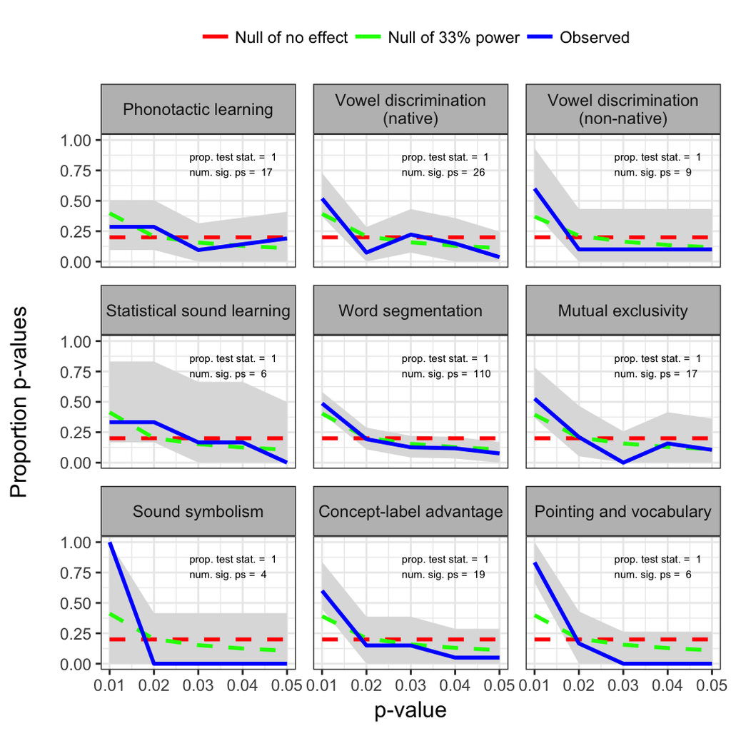

Figure S2: In the main text, we calculate p-curves based on all conditions in the dataset. In cases where a p-value was not directly available from the reported test statistic, we calculated a p-value based on a significance test using the reported means and standard deviations. The table compares the test of right-skew (Stouffer method) for this full dataset, as reported in the main text, to the subset of conditions for which p-values were directly available. Error bars are 95% confidence intervals calculated from a multinomial distribution.

```r
ALPHA <- 0.05
P_INCREMENT <- 0.01

pc.data <- get_all_pc_data(synthesis_all_data, ALPHA,
    P_INCREMENT, transform = FALSE)

p.source <- pc.data %>% select(f.transform, f.value,
    dataset, study_ID, p_round) %>% group_by(dataset) %>%
    summarise(n.total = n(), n.transform = length(which(!is.na(f.transform))),
        sig.p = length(which(p_round < ALPHA))) %>%
    mutate(stat_only = ifelse(n.total > n.transform,
        1, 0), prop.ts = 1 - n.transform/n.total, prop.ts.string = as.character(round(prop.ts,
        digits = 2)), dataset = fct_relevel(dataset,
        "Infant directed speech preference", "Phonotactic learning",
        "Vowel discrimination (native)", "Vowel discrimination (non-native)",
        "Statistical sound category learning", "Word segmentation",
        "Mutual exclusivity", "Sound symbolism", "Label advantage in concept learning",
        "Online word recognition", "Gaze following",
        "Pointing and vocabulary"), dataset = fct_recode(dataset,
        `IDS preference` = "Infant directed speech preference",
        `Statistical sound learning` = "Statistical sound category learning",
        `Concept-label advantage` = "Label advantage in concept learning",
        `Vowel discrimination\n(native)` = "Vowel discrimination (native)",
        `Vowel discrimination\n(non-native)` = "Vowel discrimination (non-native)")) %>%
    as.data.frame()

ci.data = pc.data %>% split(.$dataset, drop = TRUE) %>%
    map_df(function(data) get_all_CIS_multi(data, ALPHA,
        P_INCREMENT)) %>% mutate(dataset = fct_recode(dataset,
    `IDS preference` = "Infant directed speech preference",
    `Statistical sound learning` = "Statistical sound category learning",
    `Concept-label advantage` = "Label advantage in concept learning",
    `Vowel discrimination\n(native)` = "Vowel discrimination (native)",
    `Vowel discrimination\n(non-native)` = "Vowel discrimination (non-native)"))

ci.data[ci.data$dataset == "Sound symbolism" & ci.data$p ==
    0.01, "ci.lower"] = 0  # there's only one datapoint for this dataset

pc_plot_data <- pc.data %>% group_by(dataset) %>% do(get_p_curve_df(.,
    ALPHA, P_INCREMENT)) %>% ungroup() %>% mutate(dataset = fct_relevel(dataset,
    "Infant directed speech preference", "Phonotactic learning",
    "Vowel discrimination (native)", "Vowel discrimination (non-native)",
    "Statistical sound category learning", "Word segmentation",
    "Mutual exclusivity", "Sound symbolism", "Label advantage in concept learning",
    "Online word recognition", "Gaze following", "Pointing and vocabulary"),
    dataset = fct_recode(dataset, `IDS preference` = "Infant directed speech preference",
        `Statistical sound learning` = "Statistical sound category learning",
        `Concept-label advantage` = "Label advantage in concept learning",
        `Vowel discrimination\n(native)` = "Vowel discrimination (native)",
        `Vowel discrimination\n(non-native)` = "Vowel discrimination (non-native)"))

ggplot(pc_plot_data) + facet_wrap(~dataset, nrow = 3) +
    geom_ribbon(aes(ymin = ci.lower, ymax = ci.upper,
        x = p), fill = "grey87", data = ci.data) +
    geom_line(size = 1, aes(x = p, y = value, linetype = measure,
        color = measure)) + scale_colour_manual(name = "",
    values = c("red", "green", "blue"), labels = c("Null of no effect",
        "Null of 33% power", "Observed")) + scale_linetype_manual(values = c("dashed",
    "dashed", "solid"), guide = FALSE) + ylab("Proportion p-values\n") +
    xlab("p-value") + geom_text(aes(label = paste("prop. test stat. = ",
    prop.ts.string, "\nnum. sig. ps = ", sig.p), x = 0.028,
    y = 0.8), data = p.source, colour = "black", size = 2,
    hjust = 0) + theme_bw() + theme(legend.position = "top",
    legend.key = element_blank(), legend.background = element_rect(fill = "transparent"),
    strip.text.x = element_text(size = 9), axis.title = element_text(colour = "black",
        size = 12), panel.margin = unit(0.65, "lines"),
    strip.background = element_rect(fill = "grey"))
```

We next compare the test of right-skew presented in the main text for both the full set of p-values and those only derived from test statistics. In no case does the significance of the test differ between the two analyses.

```r
stouffer.data <- pc.data %>% group_by(dataset) %>%
    do(data.frame(stouffer = stouffer_test(., ALPHA))) %>%
    filter(stouffer.pp.measure == "ppr.full") %>% full_join(synthesis_meta_data %>%
    select(name, short_name), by = c(dataset = "name")) %>%
    select(short_name, stouffer.Z.pp, stouffer.p.Z.pp) %>%
    mutate_at(c("stouffer.p.Z.pp", "stouffer.Z.pp"),
        funs(round(., digits = 2))) %>% mutate(stouff_string = ifelse(is.na(as.character(stouffer.Z.pp)),
    "", paste0(stouffer.Z.pp, " (", stouffer.p.Z.pp,
        ")"))) %>% mutate(stouff_string = sub("(0)",
    "(< .01)", stouff_string, fixed = T)) %>% select(dataset,
    stouff_string)

# p-curve data using from all conditions (same as
# reported in paper)
stouffer.data_all <- get_all_pc_data(synthesis_all_data,
    ALPHA, P_INCREMENT, transform = TRUE) %>% group_by(dataset) %>%
    do(data.frame(stouffer = stouffer_test(., ALPHA))) %>%
    filter(stouffer.pp.measure == "ppr.full") %>% full_join(synthesis_meta_data %>%
    select(name, short_name), by = c(dataset = "name")) %>%
    select(short_name, stouffer.Z.pp, stouffer.p.Z.pp) %>%
    mutate_each_(funs(round(., digits = 2)), vars = c("stouffer.p.Z.pp",
        "stouffer.Z.pp")) %>% mutate(stouff_string = ifelse(is.na(as.character(stouffer.Z.pp)),
    "", paste0(stouffer.Z.pp, " (", stouffer.p.Z.pp,
        ")")), stouff_string = sub("(0)", "(< .01)",
    stouff_string, fixed = T)) %>% select(dataset,
    stouff_string)

stouffer_df <- left_join(stouffer.data_all, stouffer.data,
    by = "dataset") %>% .[c(2, 6, 10, 11, 9, 12, 4,
    8, 3, 5, 1, 7), ]

kable(stouffer_df, col.names = c("Phenomenon", "p-curve skew  (all conditions)",
    "p-curve skew (p-values only from test-statistics)"),
    align = c("l", "r", "r"))
```

| Phenomenon | p-curve skew (all conditions) | p-curve skew (p-values only from test-statistics) |
| --- | --- | --- |
| Infant directed speech preference | -10.4 (< .01) |  |
| Phonotactic learning | -1.52 (0.06) | -1.52 (0.06) |
| Vowel discrimination (native) | -9.96 (< .01) | -5.48 (< .01) |
| Vowel discrimination (non-native) | -8.89 (< .01) | -3.24 (< .01) |
| Statistical sound category learning | -2.96 (< .01) | -1.86 (0.03) |
| Word segmentation | -9.4 (< .01) | -9.82 (< .01) |
| Mutual exclusivity | -12.87 (< .01) | -5 (< .01) |
| Sound symbolism | -5.56 (< .01) | -5.1 (< .01) |
| Label advantage in concept learning | -4.79 (< .01) | -4.54 (< .01) |
| Online word recognition | -14.51 (< .01) |  |
| Gaze following | -18.66 (< .01) |  |
| Pointing and vocabulary | -6.33 (< .01) | -6.33 (< .01) |

## Method heterogeneity

The plot below presents the developmental trajectory of each phenomenon, with a separate color for each method. Lines show log-linear model fits. Word Segmentation shows the most notable interaction between age and method: Effect sizes increase with age for head-turn preference procedure, but decrease for central fixation (see Bergmann, et al., in press for a more complete report of method heterogenity in the dataset).

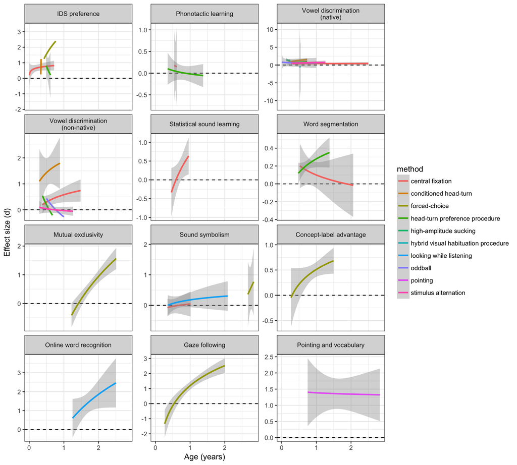

```r
synthesis_all_data %>% filter(mean_age_1/365 < 3) %>%
    mutate(dataset = as.factor(dataset), dataset = gdata::reorder.factor(dataset,
        new.order = c(2, 6, 10, 11, 9, 12, 4, 8, 3,
            5, 1, 7)), dataset = fct_recode(dataset,
        `IDS preference` = "Infant directed speech preference",
        `Statistical sound learning` = "Statistical sound category learning",
        `Concept-label advantage` = "Label advantage in concept learning",
        `Vowel discrimination\n(native)` = "Vowel discrimination (native)",
        `Vowel discrimination\n(non-native)` = "Vowel discrimination (non-native)")) %>%
    ggplot(aes(x = mean_age_1/365, y = d_calc, color = method)) +
    geom_hline(yintercept = 0, linetype = "dashed",
        color = "black") + facet_wrap(~dataset, scales = "free_y",
    ncol = 3) + geom_smooth(method = "lm", formula = y ~
    log(x)) + xlab("Age (years)") + ylab("Effect size (d)") +
    theme_bw() + theme(legend.position = "right", legend.key = element_blank(),
    legend.background = element_rect(fill = "transparent"))
```

## References

Bergmann, C., & Cristia, A. (in press). Development of infants’ segmentation of words from native speech: A meta-analytic approach. *Developmental Science*.

Bergmann, C., Tsuji, S., Piccinini, P., Lewis, M., Braginsky, M., Frank, M., & Cristia, A. (in press). Promoting replicability in developmental research through meta-analyses:Insights from language acquisition research. *Child Development*.

Colonnesi, C., Stamsa, G. J., Kostera, I., & Noomb, M. J. (2010). The relation between pointing and language development: A meta-analysis. *Developmental Review*, 30, 352–366.

Cristia, A. (in press). Can infants learn phonology in the lab? A meta-analytic answer. *Cognition*.

Dunst, C. J., Gorman, E., & Hamby, D. W. (2012). Preference for infant-directed speech in preverbal young children. *Center for Early Literacy Learning*, *5*(1).

Frank, M. C., Lewis, M., & MacDonald, K. (2016). A performance model for early word learning. In *Proceedings of the 38th Annual Conference of the Cognitive Science Society*.

Hedges, L. V., & Olkin, I. (2014). *Statistical methods for meta-analysis*. Academic Press.

Lammertink, I., Fort, M., Peperkamp, S., Fikkert, P., Guevara-Rukoz, A., & Tsuji, S. (2016). SymBuki: A meta-analysis on the sound-symbolic bouba-kiki effect in infants and toddlers. Poster presented at the XXI Biennial International Congress of Infant Studies, New Orleans, USA.

Lewis, M. & Frank, M. (in prep.). Mutual exclusivity: A meta-analysis.

Lewis, M. & Long, B. (unpublished). A meta-analysis of the concept-label advantage.

Tsuji, S. & Cristia, A. (2014). Perceptual attunement in vowels: A meta-analysis. *Developmental Psychobiology*, *56*(2), 179-191.

Viechtbauer, W. (2010). Conducting meta-analyses in R with the metafor package. *Journal of Statistical Software*, *36*(3), 1-48. URL: http://www.jstatsoft.org/v36/i03/